# 6.4 Supervised Machine Learning: Regression

### This script contains the following:

#### 1. Importing libraries and data

#### 2. Data cleaning

#### 3. Regression Analysis: disability_employment vs employment_gap

#### 4. Regression Analysis: disability_poverty vs poverty_gap

## 1. Importing Libraries and Data

```python
import pandas as pd
import numpy as np
import seaborn as sns
import matplotlib
import matplotlib.pyplot as plt
import os
import sklearn
from sklearn.model_selection import train_test_split
from sklearn.linear_model import LinearRegression
from sklearn.metrics import mean_squared_error, r2_score
```

```python
# This option ensures that the graphs you create are displayed within the notebook without the need to "call" them specifically.

%matplotlib inline
```

```python
path = r"D:\Users\Marlo\OneDrive\OneDrive - South Washington County Schools\Home\job support\Coursework\Achievement 6\Disability Statistics"
```

```python
employ = pd.read_csv(os.path.join(path, '02 Data', 'Prepared Data', 'employ3.csv'))
```

## 2. Data Cleaning

```python
employ.columns
```

```
Index(['state', 'total_pop', 'disability_category', 'race', 'gender',
       'employed_count', 'disability_employed', 'no_disability_employed',
       'employment_gap', 'poverty_count', 'disability_poverty',
       'no_disability_poverty', 'poverty_gap'],
      dtype='object')
```

```python
employ.head()
```

|  | state | total_pop | disability_category | race | gender | employed_count | disability_employed | no_disability_employed | employment_gap | poverty_count | disability_poverty | no_disability_poverty | poverty_gap |
| --- | --- | --- | --- | --- | --- | --- | --- | --- | --- | --- | --- | --- | --- |
| 0 | AL | 427044 | All | All | All | 138077 | 32.3 | 74.6 | 42.3 | 117608 | 27.5 | 14.4 | 13.1 |
| 1 | AK | 57446 | All | All | All | 26466 | 46.1 | 74.9 | 28.8 | 13785 | 24.0 | 9.1 | 14.9 |
| 2 | AZ | 462266 | All | All | All | 203672 | 44.1 | 76.0 | 31.9 | 101643 | 22.0 | 12.1 | 9.9 |
| 3 | AR | 270410 | All | All | All | 95322 | 35.3 | 76.8 | 41.5 | 75911 | 28.1 | 14.4 | 13.7 |
| 4 | CA | 2094680 | All | All | All | 825876 | 39.4 | 73.5 | 34.1 | 470724 | 22.5 | 11.3 | 11.2 |

```python
employ.shape
```

```
(401, 13)
```

##### Missing Values

```python
#Check for missing values
employ.isnull().sum()
```

```
state                     0
total_pop                 0
disability_category       0
race                      0
gender                    0
employed_count            0
disability_employed       0
no_disability_employed    0
employment_gap            0
poverty_count             0
disability_poverty        0
no_disability_poverty     0
poverty_gap               0
dtype: int64
```

##### Duplicates Check

```python
dups = employ.duplicated()
```

```python
dups.shape
```

```
(401,)
```

There are no duplicates.

##### Extreme Values Check

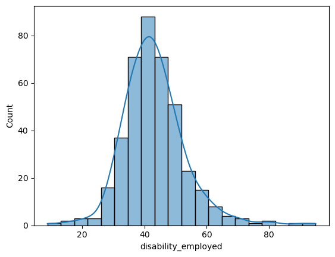

```python
sns.histplot(employ['disability_employed'], bins=20, kde = True)
```

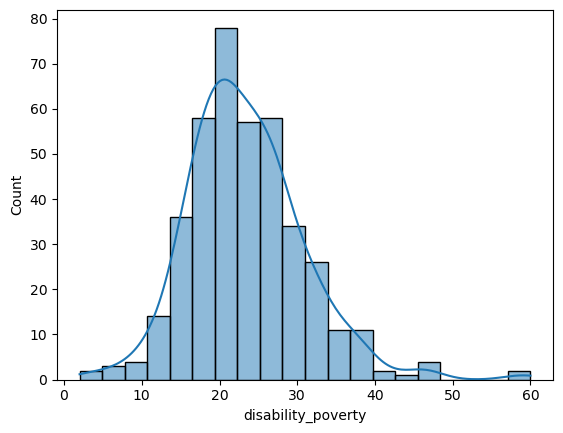

```python
sns.histplot(employ['disability_poverty'], bins=20, kde = True)
```

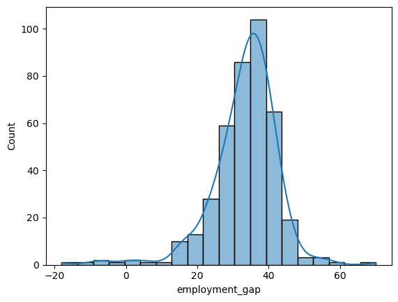

```python
sns.histplot(employ['employment_gap'], bins=20, kde = True)
```

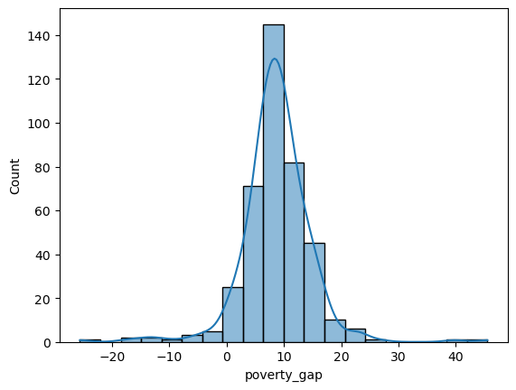

```python
sns.histplot(employ['poverty_gap'], bins=20, kde = True)
```

No significant outliers seem to be changing the data significantly.

## 3. Regression Analysis: disability_employment vs employment_gap

### Hypothesis:

The higher the number of disabled people unemployed, the higher the employment gap between disabled and non-disabled people.

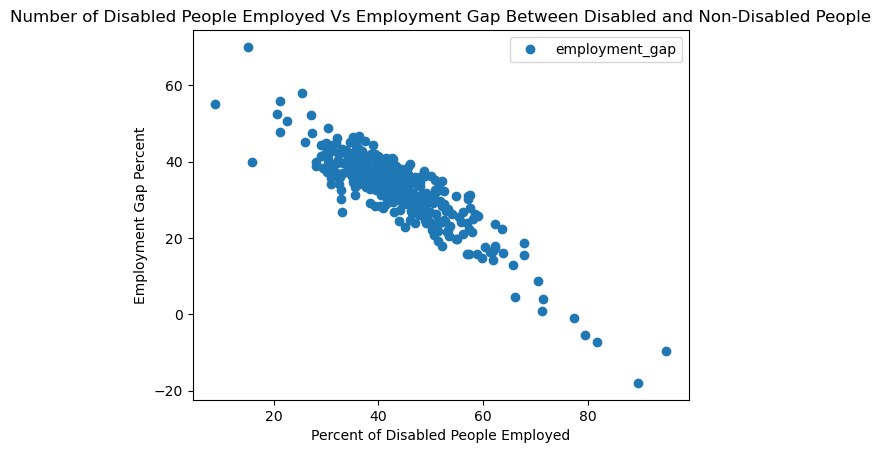

```python
# Create a scatterplot using matplotlib to show disabled_employed and employment_gap.

employ.plot(x = 'disability_employed', y='employment_gap',style='o')
plt.title('Number of Disabled People Employed Vs Employment Gap Between Disabled and Non-Disabled People')
plt.xlabel('Percent of Disabled People Employed')
plt.ylabel('Employment Gap Percent')
plt.show()
```

```python
# Reshape the variables into NumPy arrays and put them into separate objects.

X = employ['disability_employed'].values.reshape(-1,1)
y = employ['employment_gap'].values.reshape(-1,1)
```

```python
# Split data into a training set and a test set.

X_train, X_test, y_train, y_test = train_test_split(X, y, test_size=0.3, random_state=0)
```

```python
# Create a regression object.

regression = LinearRegression()
```

```python
# Fit the regression object onto the training set.

regression.fit(X_train, y_train)
```

```
LinearRegression()
```

```python
# Predict the values of y using X.

y_predicted = regression.predict(X_test)
```

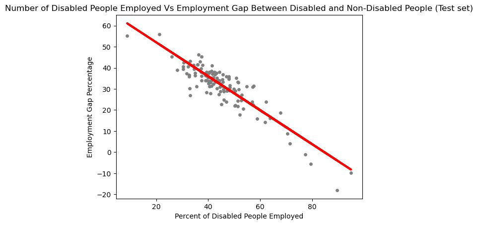

```python
# Create a plot that shows the regression line from the model on the test set.

plot_test = plt
plot_test.scatter(X_test, y_test, color='gray', s = 15)
plot_test.plot(X_test, y_predicted, color='red', linewidth =3)
plot_test.title('Number of Disabled People Employed Vs Employment Gap Between Disabled and Non-Disabled People (Test set)')
plot_test.xlabel('Percent of Disabled People Employed')
plot_test.ylabel('Employment Gap Percentage')
plot_test.show()
```

The line appears to fit the data well overall. There is a highly-concentrated area of data in the middle that might alter the results slightly, but even the dots that are not in that highly-concentrated area are close to the line.

```python
# Create objects that contain the model summary statistics.

rmse = mean_squared_error(y_test, y_predicted)
r2 = r2_score(y_test, y_predicted)
```

```python
# Print the model summary statistics. This is where you evaluate the performance of the model.

print('Slope:' ,regression.coef_)
print('Mean squared error: ', rmse)
print('R2 score: ', r2)
```

```
Slope: [[-0.80400357]]
Mean squared error:  22.366028446818415
R2 score:  0.8087292782482841
```

```python
# Create a dataframe comparing the actual and predicted values of y.

employ_data = pd.DataFrame({'Actual': y_test.flatten(), 'Predicted': y_predicted.flatten()})
employ_data.head(30)
```

|  | Actual | Predicted |
| --- | --- | --- |
| 0 | 27.8 | 35.287183 |
| 1 | 35.2 | 27.327547 |
| 2 | 23.8 | 18.001106 |
| 3 | 31.1 | 24.111533 |
| 4 | 38.5 | 34.965581 |
| 5 | 22.4 | 22.021124 |
| 6 | 36.2 | 38.101195 |
| 7 | 34.1 | 36.895190 |
| 8 | 37.6 | 34.161578 |
| 9 | 8.8 | 11.488677 |
| 10 | 34.1 | 34.000777 |
| 11 | 37.5 | 33.437974 |
| 12 | 30.3 | 41.719211 |
| 13 | 18.8 | 13.659486 |
| 14 | 29.1 | 27.649149 |
| 15 | 33.1 | 35.287183 |
| 16 | 35.5 | 36.010786 |
| 17 | 42.4 | 43.568419 |
| 18 | -18.0 | -3.867791 |
| 19 | 32.4 | 34.402779 |
| 20 | 38.1 | 34.000777 |
| 21 | 41.6 | 39.307200 |
| 22 | 22.3 | 27.568748 |
| 23 | 35.9 | 29.578757 |
| 24 | 15.9 | 20.895519 |
| 25 | 37.6 | 40.030804 |
| 26 | 39.6 | 38.181595 |
| 27 | 35.9 | 30.302360 |
| 28 | 55.8 | 51.045653 |
| 29 | 33.1 | 26.684344 |

##### Compare how the regression fits the training set

```python
# Predict.

y_predicted_train = regression.predict(X_train)
```

```python
rmse = mean_squared_error(y_train, y_predicted_train)
r2 = r2_score(y_train, y_predicted_train)
```

```python
print('Slope:' ,regression.coef_)
print('Mean squared error: ', rmse)
print('R2 score: ', r2)
```

```
Slope: [[-0.80400357]]
Mean squared error:  17.032600486409397
R2 score:  0.7604981058360414
```

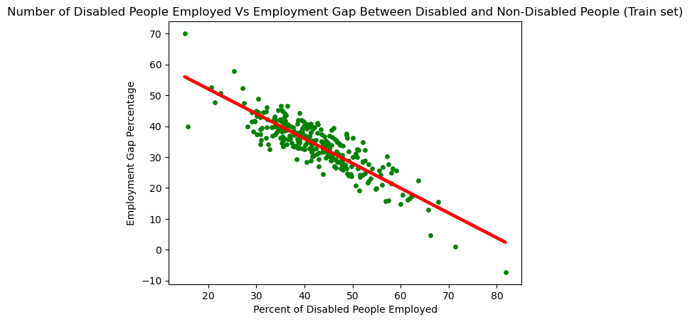

```python
# Visualizing the training set results.

plot_test = plt
plot_test.scatter(X_train, y_train, color='green', s = 15)
plot_test.plot(X_train, y_predicted_train, color='red', linewidth =3)
plot_test.title('Number of Disabled People Employed Vs Employment Gap Between Disabled and Non-Disabled People (Train set)')
plot_test.xlabel('Percent of Disabled People Employed')
plot_test.ylabel('Employment Gap Percentage')
plot_test.show()
```

Overall, I think the model performed well on the test set. The R2 score is different by 0.05 and the MSE is different by 5. Both R2 scores are over 0.75 and both MSEs are under 25. This data could be more accurate if there were more data points.

### Hypothesis:

The higher the number of disabled people in poverty, the higher gap there is between disabled and non-disabled people in poverty.

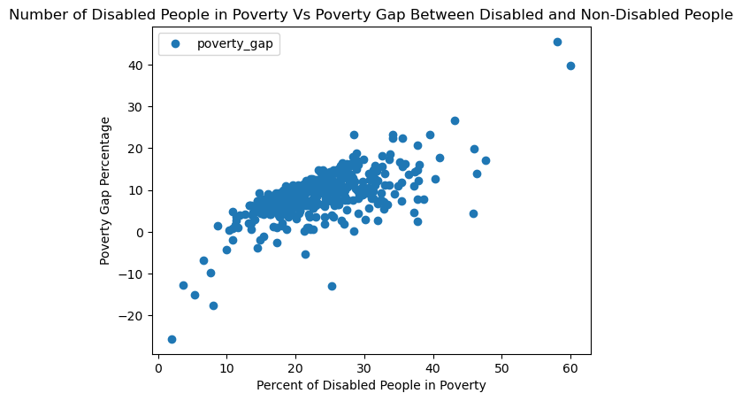

```python
# Create a scatterplot using matplotlib to show disabled_poverty and poverty_gap.

employ.plot(x = 'disability_poverty', y='poverty_gap',style='o')
plt.title('Number of Disabled People in Poverty Vs Poverty Gap Between Disabled and Non-Disabled People')
plt.xlabel('Percent of Disabled People in Poverty')
plt.ylabel('Poverty Gap Percentage')
plt.show()
```

```python
# Reshape the variables into NumPy arrays and put them into separate objects.

X = employ['disability_poverty'].values.reshape(-1,1)
y = employ['poverty_gap'].values.reshape(-1,1)
```

```python
# Split data into a training set and a test set.

X_train, X_test, y_train, y_test = train_test_split(X, y, test_size=0.3, random_state=0)
```

```python
# Create a regression object.

regression = LinearRegression()
```

```python
# Fit the regression object onto the training set.

regression.fit(X_train, y_train)
```

```
LinearRegression()
```

```python
# Predict the values of y using X.

y_predicted = regression.predict(X_test)
```

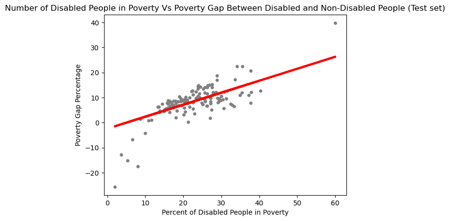

```python
# Create a plot that shows the regression line from the model on the test set.

plot_test = plt
plot_test.scatter(X_test, y_test, color='gray', s = 15)
plot_test.plot(X_test, y_predicted, color='red', linewidth =3)
plot_test.title('Number of Disabled People in Poverty Vs Poverty Gap Between Disabled and Non-Disabled People (Test set)')
plot_test.xlabel('Percent of Disabled People in Poverty')
plot_test.ylabel('Poverty Gap Percentage')
plot_test.show()
```

The line does not appear to fit the data as well. . There is a highly-concentrated area of data in the middle that might alter the results slightly. The dots that are not in the highly-concentrated area of data are not close to the line. The data seems to suggest more logarithmic versus linear.

```python
# Create objects that contain the model summary statistics.

rmse = mean_squared_error(y_test, y_predicted)
r2 = r2_score(y_test, y_predicted)
```

```python
# Print the model summary statistics. This is where you evaluate the performance of the model.

print('Slope:' ,regression.coef_)
print('Mean squared error: ', rmse)
print('R2 score: ', r2)
```

```
Slope: [[0.47804055]]
Mean squared error:  24.499245007783667
R2 score:  0.5243537880602681
```

```python
# Create a dataframe comparing the actual and predicted values of y.

employ_data = pd.DataFrame({'Actual': y_test.flatten(), 'Predicted': y_predicted.flatten()})
employ_data.head(30)
```

|  | Actual | Predicted |
| --- | --- | --- |
| 0 | 9.9 | 10.607331 |
| 1 | 7.8 | 5.157668 |
| 2 | 12.7 | 8.312736 |
| 3 | 7.5 | 5.253276 |
| 4 | 7.6 | 6.209357 |
| 5 | 2.0 | 6.257161 |
| 6 | 8.4 | 9.938074 |
| 7 | 12.2 | 10.894155 |
| 8 | 18.8 | 11.419999 |
| 9 | -17.5 | 1.428952 |
| 10 | 15.0 | 10.463918 |
| 11 | 8.5 | 7.261047 |
| 12 | 10.9 | 14.288243 |
| 13 | -4.3 | 2.385033 |
| 14 | 8.4 | 6.543986 |
| 15 | 8.5 | 7.308851 |
| 16 | 10.5 | 8.981993 |
| 17 | 7.5 | 13.093141 |
| 18 | -6.7 | 0.759695 |
| 19 | 1.1 | 3.149898 |
| 20 | 8.4 | 6.830810 |
| 21 | 15.3 | 10.798547 |
| 22 | 11.0 | 15.387736 |
| 23 | 6.1 | 5.348884 |
| 24 | 6.9 | 6.974222 |
| 25 | 11.9 | 14.527263 |
| 26 | 0.8 | 2.767465 |
| 27 | 17.1 | 11.372195 |
| 28 | 22.5 | 13.905810 |
| 29 | 8.7 | 5.444493 |

##### Compare how the regression fits the training set

```python
# Predict.

y_predicted_train = regression.predict(X_train)
```

```python
rmse = mean_squared_error(y_train, y_predicted_train)
r2 = r2_score(y_train, y_predicted_train)
```

```python
print('Slope:' ,regression.coef_)
print('Mean squared error: ', rmse)
print('R2 score: ', r2)
```

```
Slope: [[0.47804055]]
Mean squared error:  18.03890389281845
R2 score:  0.3940809869636156
```

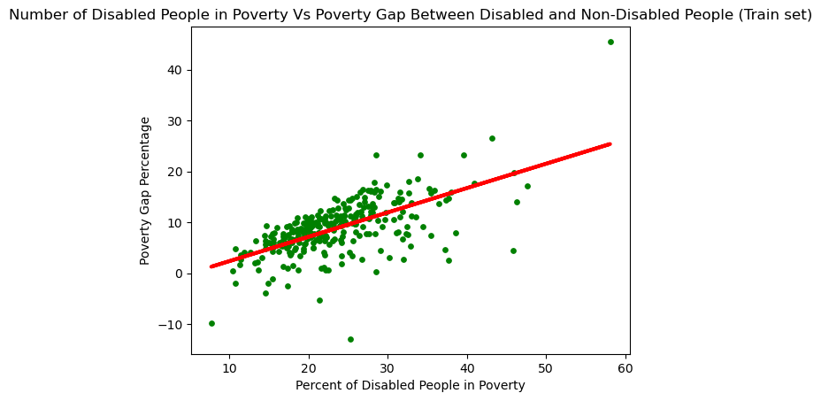

```python
# Visualizing the training set results.

plot_test = plt
plot_test.scatter(X_train, y_train, color='green', s = 15)
plot_test.plot(X_train, y_predicted_train, color='red', linewidth =3)
plot_test.title('Number of Disabled People in Poverty Vs Poverty Gap Between Disabled and Non-Disabled People (Train set)')
plot_test.xlabel('Percent of Disabled People in Poverty')
plot_test.ylabel('Poverty Gap Percentage')
plot_test.show()
```

Overall, I do not think the model performed well on the test set. The R2 score is different by 0.13 and the MSE is different by 6. While both MSEs are under 25 the R2 scores were 0.39 and 0.52 which means it is not a good fit. This data could be more accurate if there were more data points. It is possible there is sample bias since some of this data came from samples.

## 5. Regression Analysis: disability_poverty vs. disability_employed

#### Hypothesis:

• The higher the number of disabled people in unemployed, the higher the number of disabled people in poverty.

```python
#Clean extreme values in "disability_count"
employ = employ[employ['disability_poverty']<60]
```

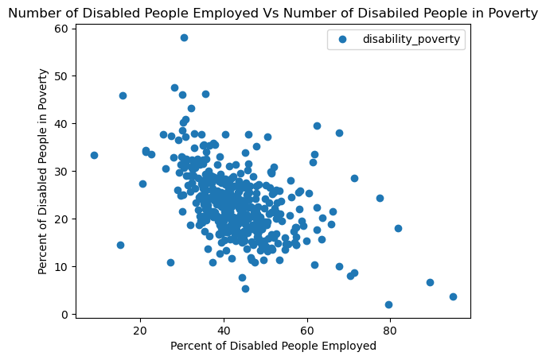

```python
# Create a scatterplot using matplotlib to show disabled_employed and employment_gap.

employ.plot(x = 'disability_employed', y='disability_poverty',style='o')
plt.title('Number of Disabled People Employed Vs Number of Disabiled People in Poverty')
plt.xlabel('Percent of Disabled People Employed')
plt.ylabel('Percent of Disabled People in Poverty')
plt.show()
```

```python
# Reshape the variables into NumPy arrays and put them into separate objects.

X = employ['disability_employed'].values.reshape(-1,1)
y = employ['disability_poverty'].values.reshape(-1,1)
```

```python
# Split data into a training set and a test set.

X_train, X_test, y_train, y_test = train_test_split(X, y, test_size=0.3, random_state=0)
```

```python
# Create a regression object.

regression = LinearRegression()
```

```python
# Fit the regression object onto the training set.

regression.fit(X_train, y_train)
```

```
LinearRegression()
```

```python
# Predict the values of y using X.

y_predicted = regression.predict(X_test)
```

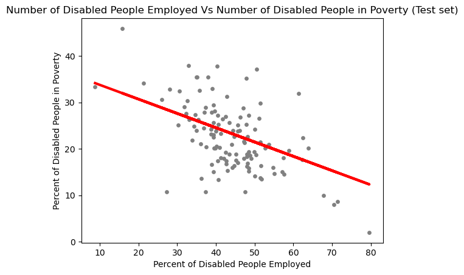

```python
# Create a plot that shows the regression line from the model on the test set.

plot_test = plt
plot_test.scatter(X_test, y_test, color='gray', s = 15)
plot_test.plot(X_test, y_predicted, color='red', linewidth =3)
plot_test.title('Number of Disabled People Employed Vs Number of Disabled People in Poverty (Test set)')
plot_test.xlabel('Percent of Disabled People Employed')
plot_test.ylabel('Percent of Disabled People in Poverty')
plot_test.show()
```

The line does not fit the data well.

```python
# Create objects that contain the model summary statistics.

rmse = mean_squared_error(y_test, y_predicted)
r2 = r2_score(y_test, y_predicted)
```

```python
# Print the model summary statistics. This is where you evaluate the performance of the model.

print('Slope:' ,regression.coef_)
print('Mean squared error: ', rmse)
print('R2 score: ', r2)
```

```
Slope: [[-0.30769371]]
Mean squared error:  37.36178057176832
R2 score:  0.2900658661478489
```

```python
# Create a dataframe comparing the actual and predicted values of y.

employ_data = pd.DataFrame({'Actual': y_test.flatten(), 'Predicted': y_predicted.flatten()})
employ_data.head(30)
```

|  | Actual | Predicted |
| --- | --- | --- |
| 0 | 33.3 | 34.140844 |
| 1 | 20.2 | 24.694647 |
| 2 | 18.3 | 22.079251 |
| 3 | 13.6 | 25.710037 |
| 4 | 26.6 | 21.125400 |
| 5 | 15.0 | 24.725417 |
| 6 | 17.4 | 24.417723 |
| 7 | 19.4 | 21.925404 |
| 8 | 32.4 | 27.433121 |
| 9 | 33.0 | 24.848494 |
| 10 | 26.9 | 23.771566 |
| 11 | 27.4 | 26.202347 |
| 12 | 37.9 | 26.694657 |
| 13 | 14.1 | 21.433094 |
| 14 | 18.7 | 21.340786 |
| 15 | 22.4 | 17.648461 |
| 16 | 18.1 | 19.186930 |
| 17 | 37.2 | 21.310017 |
| 18 | 24.5 | 24.510031 |
| 19 | 29.4 | 24.756186 |
| 20 | 10.8 | 28.479280 |
| 21 | 20.1 | 20.633090 |
| 22 | 32.8 | 28.233125 |
| 23 | 16.2 | 22.079251 |
| 24 | 19.6 | 18.756159 |
| 25 | 18.6 | 21.833096 |
| 26 | 16.0 | 19.986934 |
| 27 | 28.8 | 22.356175 |
| 28 | 35.4 | 26.079269 |
| 29 | 30.6 | 28.848512 |

```python
# Predict.

y_predicted_train = regression.predict(X_train)
```

```python
rmse = mean_squared_error(y_train, y_predicted_train)
r2 = r2_score(y_train, y_predicted_train)
```

```python
print('Slope:' ,regression.coef_)
print('Mean squared error: ', rmse)
print('R2 score: ', r2)
```

```
Slope: [[-0.30769371]]
Mean squared error:  43.202961368446964
R2 score:  0.180964172860552
```

[figure not shown]

```python
# Visualizing the training set results.

plot_test = plt
plot_test.scatter(X_train, y_train, color='green', s = 15)
plot_test.plot(X_train, y_predicted_train, color='red', linewidth =3)
plot_test.title('Number of Disabled People in Poverty Vs Number of Disabled People Employed (Train set)')
plot_test.xlabel('Percent of Disabled People in Poverty')
plot_test.ylabel('Poverty of Disabled Peop')
plot_test.show()
```

Overall, I do not think the model performed well on the test set. The R2 score is different by 0.11 and the MSE is different by 6. Both MSEs are over 25 the R2 scores were 0.29 and 0.18 which means it is not a good fit. This data could be more accurate if there were more data points. It is possible there is sample bias since some of this data came from samples.